# R in the Lab: Two Treatments Comparison

## 1. Problem

You want to know if the consumption of a certain kind of fat can increase drastically the weight. With this purpose you decide to perform an experiment using some mouses. You have twelve animals and you randomly assign a different diet to each one. You will feed six mice with a diet containing the strange fat (diet 1) and the other six will eat a regular diet without any addition (diet 2).

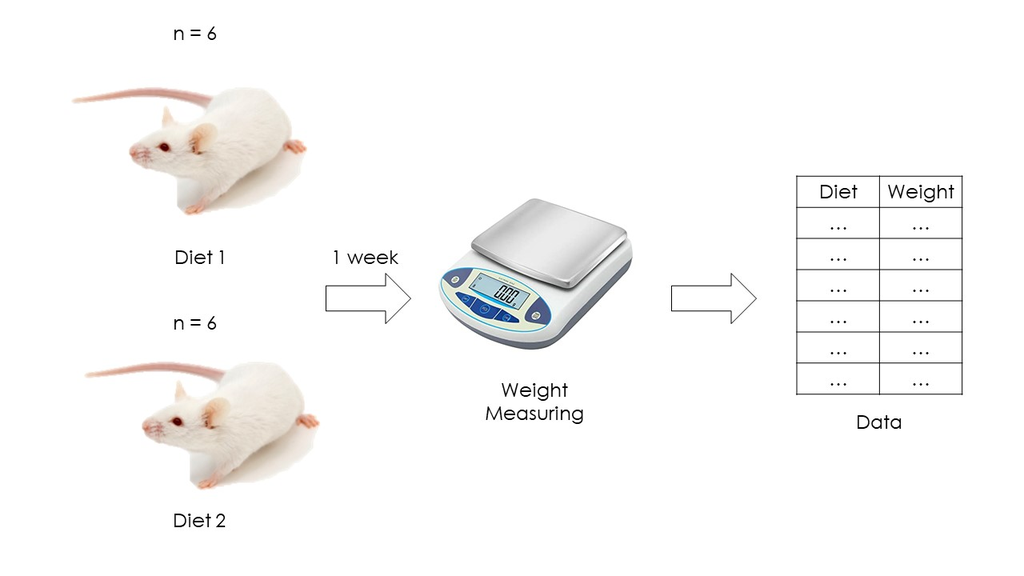

After a week you measure and register the weight of each mouse, So your data look like this:

Experimental data

| Mouse Code | Diet | Weight (g) |
| --- | --- | --- |
| 5HF | 1 | 21.99 |
| Y5Y | 1 | 24.66 |
| G29 | 1 | 21.49 |
| 10H | 1 | 23.08 |
| LLE | 1 | 25.05 |
| ET8 | 1 | 22.28 |
| TJX | 2 | 18.48 |
| JR2 | 2 | 18.30 |
| SMD | 2 | 18.69 |
| KXZ | 2 | 19.15 |
| XD9 | 2 | 20.35 |
| 974 | 2 | 18.12 |

You want to establish if there is a statistical significant difference between the diet treatments. Does the fat in diet 1 increase (or reduce) the mouse weight after a week?

## 2. Solution

First, I am assuming that you already know the R basics and, of course, you have installed R already. I am also using RStudio.

These folders should be contained in a main folder with a representative name.

- The analysis folder contains my R scripts, one script for each individual analysis.
- The data folder contains my data, my experimental data products and my analysis products when their outputs produce text or CSV files.
- The graphs folder contains the graphical outputs produced by their correspond R scripts.

This organization is not a kind of rule of thumbs. You can organize your files other ways as long as you can ensure the reproducibility and clarity of your analysis.

Finally, let’s perform a Student’s t-Test, summarize and make some visual representations of our data.

### 2.1 t-Test

Basically, a t-Test will compare the diet means taking into account the variation and the sample size of each group. You can perform this analysis following the next code:

```r
# t test on main data assuming equal variances ---------------------------

# 1 Import data

data <- read.csv("data/main_data.csv")

# 2 Perform a t test between the two treatments

t_test <- t.test(
  weight ~ diet,
  data = data,
  alternative = "two.sided",
  mu = 0,
  var.equal = TRUE
  )

# 3 Save de default output for t.test function

capture.output(t_test, file = "data/t_test_output2.txt")
```

As can you see, I performed this analysis following three steps:

- On the first step I imported the experimental data. This file is in CSV (comma-separated values) format and is located on my data folder, so the path that I wrote on this command must contain the folder name.
- On the second step I ran the t-Test properly.
- I saved the analysis result on a file called “t_test_output2.txt” and I stored it on the folder called “data”.

In the function `t.test`, the argument `weight ~ diet` indicates that I want to consider the variable `weight` depended on the variable `diet`. `data = data` indicates that the data is stored in the object called the same way. `alternative = "two.sided"` establish that we want to perform a two-tailed t test, so we are testing for the possibility of the difference between means on both directions (a positive or negative difference). `mu = 0` indicates the true value of the distribution mean and `var.equal = TRUE` indicates that our populations have the same variance.

When you type `t_test`, or open your text file, you’ll see your analysis result:

```r
t_test
```

```
##
##  Two Sample t-test
##
## data:  weight by diet
## t = 6.196, df = 10, p-value = 0.000102
## alternative hypothesis: true difference in means is not equal to 0
## 95 percent confidence interval:
##  2.717393 5.769273
## sample estimates:
## mean in group 1 mean in group 2
##        23.09167        18.84833
```

Clearly, this result shows that the diet containing the strange fat (diet 1) increased the weight mice.

You can type `?t.test` for more information about this function.

How can you be you sure about the equality of variances (the argument specified as `var.equal = TRUE`)? You can perform the next code:

```r
# F test for treatments equal variance ---------------------------------------

# Import data

data <- read.csv("data/main_data.csv")

# F test

f_test <- var.test(weight ~ diet, data = data)

# Save f_test output

capture.output(f_test, file = "data/f_test_output.txt")
```

If you type `f_test`, or open your text file, you will see the result:

```r
f_test
```

```
##
##  F test to compare two variances
##
## data:  weight by diet
## F = 3.2154, num df = 5, denom df = 5, p-value = 0.2257
## alternative hypothesis: true ratio of variances is not equal to 1
## 95 percent confidence interval:
##   0.4499362 22.9785902
## sample estimates:
## ratio of variances
##           3.215416
```

What does this mean? Briefly, it means that you can consider both variances equal. If the p-value would have been minor than 0.05, you would have had enough evidence to say that both parameters were different (variances not equal).

When the variances are not equal, you can correct your code simply by changing `var.equal = TRUE` for `var.equal = FALSE`. The last one is the default value, so you can simply skip it:

```r
# t test main data -------------------------------------------------------

# 1 Import data

data <- read.csv("data/main_data.csv")

# 2 Perform a t test between the two treatments

t_test <- t.test(
  weight ~ diet,
  data = data,
  alternative = "two.sided",
  mu = 0
  )

# 3 Save de default output for t.test function

capture.output(t_test, file = "data/t_test_output.txt")
```

You can see your results:

```r
t_test
```

```
##
##  Welch Two Sample t-test
##
## data:  weight by diet
## t = 6.196, df = 7.8357, p-value = 0.0002837
## alternative hypothesis: true difference in means is not equal to 0
## 95 percent confidence interval:
##  2.658286 5.828380
## sample estimates:
## mean in group 1 mean in group 2
##        23.09167        18.84833
```

At this example there is no such big difference, but always it is better to be sure so you can reach good conclusions about your results.

### 2.2 Summary

Next, let’s make a summary table with relevant information about our experimental data. It’s usual to include the mean and the standard deviation of each one of your treatments, but maybe you want to include more information.

I’ll use the `dplyr` package accomplish this.

```r
library(dplyr)
```

```r
# Summarizing main data ------------------------------------------------------

# 1 Import data

data <- read.csv("data/main_data.csv")

# 2 Summarize using dplyr

sum_table <- data %>%
  group_by(diet) %>%
  summarize(
    min    = min(weight),
    max    = max(weight),
    range  = max - min,
    mean   = round(mean(weight), 2),
    median = round(median(weight), 2),
    sd     = round(sd(weight), 2),
    cv     = round((sd / mean) * 100, 2)
  )

# 3 Save summary

write.csv(sum_table, file = "data/summary_table.csv", row.names = FALSE)
```

`group_by()` tells to `summarize()` to perform the operations by grouping by diet. This way, `summarize()` will obtain the statistics we want for each diet. Within this function we specify which operation we want to perform over the response variable (the mice weight).

I performed this analysis following the same pattern: import your data > make your analysis > save your results. You can skip the first step if you are working on the same session. Personally, I prefer to work on a “modular way” (one script for each analysis), thus I can reproduce or edit an analysis without depending on another one.

If you save your tables as CSV files, when you edit them to look better, be sure to save it as XLS files or a related one, this way you won’t lose your editions. My final sumamry table looks like this:

Data summary

| Diet | Min | Max | Range | Mean | Median | SD | CV (%) |
| --- | --- | --- | --- | --- | --- | --- | --- |
| 1 | 21.49 | 25.05 | 3.56 | 23.09 | 22.68 | 1.47 | 6.37 |
| 2 | 18.12 | 20.35 | 2.23 | 18.85 | 18.59 | 0.82 | 4.35 |

### 2.3 Plots

Finally, let’s represent our data by doing a good graph. Frequently this is performed by making a bar graph to represent each treatment mean and its standard deviation as an error bar.

I’ll use `ggplot2` to make this:

```r
library(ggplot2)
```

I recently found useful to set a global theme that can be applied to each graph. I put this code in a separate script, and run it first:

```r
# Set theme for all graphs ------------------------------------------------

theme_set(
  theme_classic() +
    theme(axis.text.x = element_text(color = "black", size = 13),
          axis.text.y = element_text(color = "black", size = 13),
          axis.title = element_text(color = "black", size = 15))
)
```

```r
source("analysis/theme.R")
```

On this chunk of code I just settled the classic theme (`theme_classic()`) and changed the default color and size of `axis.text.x`, `axis.text.y` and `axis.title`. You can customize your plot themes in multiple ways, but personally I prefer to keep it as simple as possible.

The next code produces a bar graph using the summary table made in the last section.

```r
# Bar Graph for summary table -------------------------------------------------

# 1 Importing the data

sum_table <- read.csv("data/summary_table.csv")

# 2 Bar graph

bar_graph <- ggplot(data = sum_table, aes(x = as.factor(diet), y = mean)) +
  geom_col(width = 0.2, color = "black", fill = "royalblue1") +
  geom_errorbar(aes(ymin = mean - sd, ymax = mean + sd), width = 0.05) +
  xlab("Diet") +
  ylab("Weight (g)")

# 3 Save plot

ggsave(bar_graph, filename = "graphs/bargraph.jpeg")
```

I followed the same pattern than in the last sections: import data > make the graph > save the graph.

`data = sum_table` set where is our data while the code `x = as.factor(diet)` indicates to the functions consider the variable `diet` on the x axis as a categorical variable, not as continuous one. `y = mean` set which variable will be plotted on the y axis (the `mean` column in `sum_table`) . `xlab()` changes the default x axis label, likewise `ylab()` that changes the default y axis label.

In the last command (`ggsave(bar_graph, filename = "graphs/bargraph.jpeg")`), I saved my plot as a JPEG file on my graphs folder. You can click on it to see the results or type on your console:

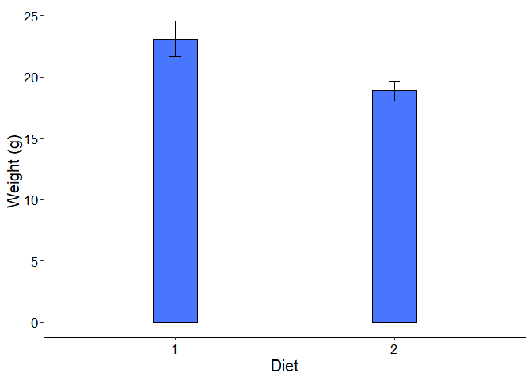

```r
bar_graph
```

R and RStudio allow us to be a bit creative and represent our data in other ways. The next code will made a point graph for each diet, with a horizontal blue line representing the median.

```r
# Point graph for each category -------------------------------------

# 1 Importing the data

data <- read.csv("data/main_data.csv")

# 2 Point graph

point_graph <- ggplot(data = data, aes(x = as.factor(diet), y = weight)) +
  geom_point() +
  stat_summary(fun = median, geom = "crossbar", width = 0.2, col = "blue") +
  xlab("Diet") +
  ylab("Weight (g)")

# 3 Save plot

ggsave(point_graph, filename = "graphs/pointgraph.jpeg")
```

At the end the code will produce the next graph:

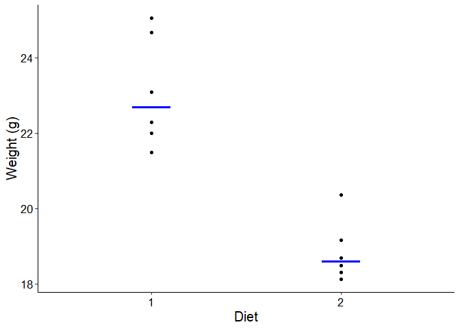

```r
point_graph
```

`ggplot2` works like stacking layers, each layer containing a plot element. This enables to combine different types of graphs. The next code combines the bar and point graphs:

```r
# Bar Graph for summary table -------------------------------------------------

# 1 Importing the data

sum_table <- read.csv("data/summary_table.csv")
data <- read.csv("data/main_data.csv")

# 2 Bar graph

barpoint_graph <- ggplot(data = sum_table, aes(x = as.factor(diet), y = mean)) +
  geom_col(
    width = 0.2,
    color = "black", fill = "royalblue1"
    ) +
  geom_errorbar(
    aes(ymin = mean - sd, ymax = mean + sd), width = 0.05
    ) +
  geom_point(
    data = data,
    aes(x = as.factor(diet), y = weight),
    color = "blue4", size = 1.5
    ) +
  xlab("Diet") +
  ylab("Weight (g)")

# 3 Save plot

ggsave(barpoint_graph, filename = "graphs/barpointgraph.jpeg")
```

You need to tell to `geom_point()` which data use, otherwise it will use the `summary_table` data specified on the `ggplot()` function.

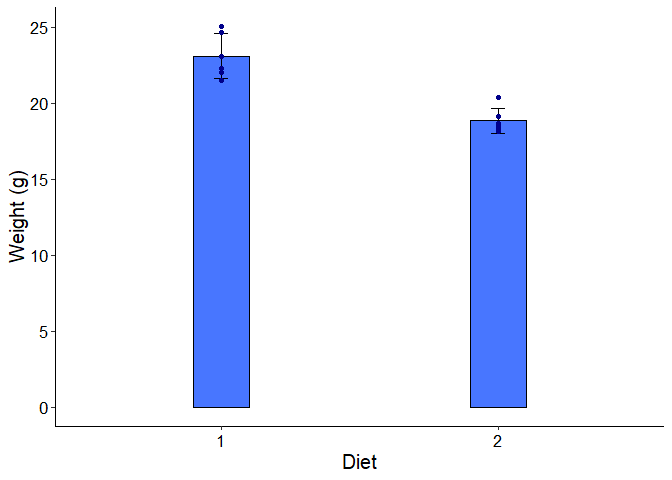

```r
barpoint_graph
```

Comparing the bar and the point plots, maybe there doesn’t seem to be too much difference, but in some cases bar plots will tend to hide the real distribution of your data. Click the next link to find more information: [#BarBarPlots!](https://thenode.biologists.com/barbarplots/photo/)

That’s it! I think there is no better way to learn than learn by doing. Why don’t you try to reproduce all this analysis by yourself? Try to use your own data! You can even clone the repository for this analysis and reproduce it step by step from scratch:

[Simple Mean Analysis Repository](https://github.com/jpch26/Two-Treatments-Comparison)

Feel free to modify, improve or extend the code. It’s all yours!